# (Ford Go Bike)

## Preliminary Wrangling

>

```python
# import all packages and set plots to be embedded inline
import numpy as np
import pandas as pd
import matplotlib.pyplot as plt
import seaborn as sb

%matplotlib inline
```

```python
gobike = pd.read_csv('fordgobike-tripdata.csv')
```

```python
gobike.head()
```

|  | duration_sec | start_time | end_time | start_station_id | start_station_name | start_station_latitude | start_station_longitude | end_station_id | end_station_name | end_station_latitude | end_station_longitude | bike_id | user_type | member_birth_year | member_gender | bike_share_for_all_trip |
| --- | --- | --- | --- | --- | --- | --- | --- | --- | --- | --- | --- | --- | --- | --- | --- | --- |
| 0 | 52185 | 2019-02-28 17:32:10.1450 | 2019-03-01 08:01:55.9750 | 21.0 | Montgomery St BART Station (Market St at 2nd St) | 37.789625 | -122.400811 | 13.0 | Commercial St at Montgomery St | 37.794231 | -122.402923 | 4902 | Customer | 1984.0 | Male | No |
| 1 | 42521 | 2019-02-28 18:53:21.7890 | 2019-03-01 06:42:03.0560 | 23.0 | The Embarcadero at Steuart St | 37.791464 | -122.391034 | 81.0 | Berry St at 4th St | 37.775880 | -122.393170 | 2535 | Customer | NaN | NaN | No |
| 2 | 61854 | 2019-02-28 12:13:13.2180 | 2019-03-01 05:24:08.1460 | 86.0 | Market St at Dolores St | 37.769305 | -122.426826 | 3.0 | Powell St BART Station (Market St at 4th St) | 37.786375 | -122.404904 | 5905 | Customer | 1972.0 | Male | No |
| 3 | 36490 | 2019-02-28 17:54:26.0100 | 2019-03-01 04:02:36.8420 | 375.0 | Grove St at Masonic Ave | 37.774836 | -122.446546 | 70.0 | Central Ave at Fell St | 37.773311 | -122.444293 | 6638 | Subscriber | 1989.0 | Other | No |
| 4 | 1585 | 2019-02-28 23:54:18.5490 | 2019-03-01 00:20:44.0740 | 7.0 | Frank H Ogawa Plaza | 37.804562 | -122.271738 | 222.0 | 10th Ave at E 15th St | 37.792714 | -122.248780 | 4898 | Subscriber | 1974.0 | Male | Yes |

```python
#Checking the data set for Null values and appropriate data types.
gobike.info()
```

```
<class 'pandas.core.frame.DataFrame'>
RangeIndex: 183412 entries, 0 to 183411
Data columns (total 16 columns):
 #   Column                   Non-Null Count   Dtype
---  ------                   --------------   -----
 0   duration_sec             183412 non-null  int64
 1   start_time               183412 non-null  object
 2   end_time                 183412 non-null  object
 3   start_station_id         183215 non-null  float64
 4   start_station_name       183215 non-null  object
 5   start_station_latitude   183412 non-null  float64
 6   start_station_longitude  183412 non-null  float64
 7   end_station_id           183215 non-null  float64
 8   end_station_name         183215 non-null  object
 9   end_station_latitude     183412 non-null  float64
 10  end_station_longitude    183412 non-null  float64
 11  bike_id                  183412 non-null  int64
 12  user_type                183412 non-null  object
 13  member_birth_year        175147 non-null  float64
 14  member_gender            175147 non-null  object
 15  bike_share_for_all_trip  183412 non-null  object
dtypes: float64(7), int64(2), object(7)
memory usage: 22.4+ MB
```

```python
#Checking for duplicates
gobike.duplicated().sum()
```

```
0
```

```python
gobike.describe()
```

|  | duration_sec | start_station_id | start_station_latitude | start_station_longitude | end_station_id | end_station_latitude | end_station_longitude | bike_id | member_birth_year |
| --- | --- | --- | --- | --- | --- | --- | --- | --- | --- |
| count | 183412.000000 | 183215.000000 | 183412.000000 | 183412.000000 | 183215.000000 | 183412.000000 | 183412.000000 | 183412.000000 | 175147.000000 |
| mean | 726.078435 | 138.590427 | 37.771223 | -122.352664 | 136.249123 | 37.771427 | -122.352250 | 4472.906375 | 1984.806437 |
| std | 1794.389780 | 111.778864 | 0.099581 | 0.117097 | 111.515131 | 0.099490 | 0.116673 | 1664.383394 | 10.116689 |
| min | 61.000000 | 3.000000 | 37.317298 | -122.453704 | 3.000000 | 37.317298 | -122.453704 | 11.000000 | 1878.000000 |
| 25% | 325.000000 | 47.000000 | 37.770083 | -122.412408 | 44.000000 | 37.770407 | -122.411726 | 3777.000000 | 1980.000000 |
| 50% | 514.000000 | 104.000000 | 37.780760 | -122.398285 | 100.000000 | 37.781010 | -122.398279 | 4958.000000 | 1987.000000 |
| 75% | 796.000000 | 239.000000 | 37.797280 | -122.286533 | 235.000000 | 37.797320 | -122.288045 | 5502.000000 | 1992.000000 |
| max | 85444.000000 | 398.000000 | 37.880222 | -121.874119 | 398.000000 | 37.880222 | -121.874119 | 6645.000000 | 2001.000000 |

```python
#dropping the duplicate values.
gobike = gobike.dropna()
```

```python
#Converting the time variables to pandas datatime series.
gobike['start_time'] = pd.to_datetime(gobike['start_time'])
gobike['end_time'] = pd.to_datetime(gobike['end_time'])
gobike.head()
```

|  | duration_sec | start_time | end_time | start_station_id | start_station_name | start_station_latitude | start_station_longitude | end_station_id | end_station_name | end_station_latitude | end_station_longitude | bike_id | user_type | member_birth_year | member_gender | bike_share_for_all_trip |
| --- | --- | --- | --- | --- | --- | --- | --- | --- | --- | --- | --- | --- | --- | --- | --- | --- |
| 0 | 52185 | 2019-02-28 17:32:10.145 | 2019-03-01 08:01:55.975 | 21.0 | Montgomery St BART Station (Market St at 2nd St) | 37.789625 | -122.400811 | 13.0 | Commercial St at Montgomery St | 37.794231 | -122.402923 | 4902 | Customer | 1984.0 | Male | No |
| 2 | 61854 | 2019-02-28 12:13:13.218 | 2019-03-01 05:24:08.146 | 86.0 | Market St at Dolores St | 37.769305 | -122.426826 | 3.0 | Powell St BART Station (Market St at 4th St) | 37.786375 | -122.404904 | 5905 | Customer | 1972.0 | Male | No |
| 3 | 36490 | 2019-02-28 17:54:26.010 | 2019-03-01 04:02:36.842 | 375.0 | Grove St at Masonic Ave | 37.774836 | -122.446546 | 70.0 | Central Ave at Fell St | 37.773311 | -122.444293 | 6638 | Subscriber | 1989.0 | Other | No |
| 4 | 1585 | 2019-02-28 23:54:18.549 | 2019-03-01 00:20:44.074 | 7.0 | Frank H Ogawa Plaza | 37.804562 | -122.271738 | 222.0 | 10th Ave at E 15th St | 37.792714 | -122.248780 | 4898 | Subscriber | 1974.0 | Male | Yes |
| 5 | 1793 | 2019-02-28 23:49:58.632 | 2019-03-01 00:19:51.760 | 93.0 | 4th St at Mission Bay Blvd S | 37.770407 | -122.391198 | 323.0 | Broadway at Kearny | 37.798014 | -122.405950 | 5200 | Subscriber | 1959.0 | Male | No |

```python
gobike.sample(5)
```

|  | duration_sec | start_time | end_time | start_station_id | start_station_name | start_station_latitude | start_station_longitude | end_station_id | end_station_name | end_station_latitude | end_station_longitude | bike_id | user_type | member_birth_year | member_gender | bike_share_for_all_trip |
| --- | --- | --- | --- | --- | --- | --- | --- | --- | --- | --- | --- | --- | --- | --- | --- | --- |
| 2522 | 279 | 2019-02-28 18:04:35.454 | 2019-02-28 18:09:15.324 | 343.0 | Bryant St at 2nd St | 37.783172 | -122.393572 | 21.0 | Montgomery St BART Station (Market St at 2nd St) | 37.789625 | -122.400811 | 1547 | Subscriber | 1980.0 | Male | No |
| 93254 | 244 | 2019-02-15 17:54:27.342 | 2019-02-15 17:58:32.332 | 202.0 | Washington St at 8th St | 37.800754 | -122.274894 | 203.0 | Webster St at 2nd St | 37.795195 | -122.273970 | 3746 | Subscriber | 1983.0 | Male | No |
| 121225 | 435 | 2019-02-11 15:52:18.229 | 2019-02-11 15:59:33.775 | 7.0 | Frank H Ogawa Plaza | 37.804562 | -122.271738 | 180.0 | Telegraph Ave at 23rd St | 37.812678 | -122.268773 | 5072 | Subscriber | 1988.0 | Male | No |
| 8523 | 556 | 2019-02-28 08:16:51.742 | 2019-02-28 08:26:08.577 | 29.0 | O'Farrell St at Divisadero St | 37.782405 | -122.439446 | 59.0 | S Van Ness Ave at Market St | 37.774814 | -122.418954 | 5213 | Subscriber | 1969.0 | Male | No |
| 159966 | 153 | 2019-02-05 17:35:11.191 | 2019-02-05 17:37:45.180 | 182.0 | 19th Street BART Station | 37.809013 | -122.268247 | 180.0 | Telegraph Ave at 23rd St | 37.812678 | -122.268773 | 4493 | Subscriber | 1979.0 | Male | No |

```python
#Changing the data types of ID columns from float to strings.
gobike['start_station_id'] = gobike['start_station_id'].astype('int').astype('str')
gobike['end_station_id'] = gobike['end_station_id'].astype('int').astype('str')
gobike['member_birth_year'] = gobike['member_birth_year'].astype('int')
```

```python
#Adding an Age column to facilitate analysis.
gobike['age'] = 2021 - gobike['member_birth_year']
```

```python
#Removing the 1878 year row.
gobike = gobike.drop(gobike[gobike['member_birth_year'] == 1878].index)
```

```python
#Creating columns for specific time variables.
gobike['start_year'] = gobike['start_time'].dt.year
gobike['start_month'] = gobike['start_time'].dt.month
gobike['start_day'] = gobike['start_time'].dt.day
gobike['start_hour'] = gobike['start_time'].dt.hour
```

```python
gobike['end_year'] = gobike['end_time'].dt.year
gobike['end_month'] = gobike['end_time'].dt.month
gobike['end_day'] = gobike['end_time'].dt.day
gobike['end_hour'] = gobike['end_time'].dt.hour
```

```python
#Adding a duration column in minutes.
gobike['duration_min'] = gobike['duration_sec']/60
```

# Problems in the dataset:

- Start time and end time are not in Datetime format.
- missing values in some columns.
- Start station id and bike id should be strings.
- Birth year shouldn't be a float
- drop 1878 biker row.

### What is the structure of your dataset?

```python
gobike.shape
```

```
(174951, 26)
```

```python
gobike.describe()
```

|  | duration_sec | start_station_latitude | start_station_longitude | end_station_latitude | end_station_longitude | bike_id | member_birth_year | age | start_year | start_month | start_day | start_hour | end_year | end_month | end_day | end_hour | duration_min |
| --- | --- | --- | --- | --- | --- | --- | --- | --- | --- | --- | --- | --- | --- | --- | --- | --- | --- |
| count | 174951.000000 | 174951.000000 | 174951.000000 | 174951.000000 | 174951.000000 | 174951.000000 | 174951.000000 | 174951.000000 | 174951.0 | 174951.0 | 174951.000000 | 174951.000000 | 174951.0 | 174951.000000 | 174951.000000 | 174951.000000 | 174951.000000 |
| mean | 703.998342 | 37.771220 | -122.351760 | 37.771414 | -122.351335 | 4482.576390 | 1984.803745 | 36.196255 | 2019.0 | 2.0 | 15.312282 | 13.456191 | 2019.0 | 2.000080 | 15.311659 | 13.609559 | 11.733306 |
| std | 1642.208567 | 0.100391 | 0.117732 | 0.100296 | 0.117294 | 1659.194107 | 10.115538 | 10.115538 | 0.0 | 0.0 | 8.033915 | 4.734284 | 0.0 | 0.008945 | 8.034117 | 4.748030 | 27.370143 |
| min | 61.000000 | 37.317298 | -122.453704 | 37.317298 | -122.453704 | 11.000000 | 1900.000000 | 20.000000 | 2019.0 | 2.0 | 1.000000 | 0.000000 | 2019.0 | 2.000000 | 1.000000 | 0.000000 | 1.016667 |
| 25% | 323.000000 | 37.770407 | -122.411901 | 37.770407 | -122.411647 | 3799.000000 | 1980.000000 | 29.000000 | 2019.0 | 2.0 | 8.000000 | 9.000000 | 2019.0 | 2.000000 | 8.000000 | 9.000000 | 5.383333 |
| 50% | 510.000000 | 37.780760 | -122.398279 | 37.781010 | -122.397437 | 4960.000000 | 1987.000000 | 34.000000 | 2019.0 | 2.0 | 15.000000 | 14.000000 | 2019.0 | 2.000000 | 15.000000 | 14.000000 | 8.500000 |
| 75% | 789.000000 | 37.797320 | -122.283093 | 37.797673 | -122.286533 | 5505.000000 | 1992.000000 | 41.000000 | 2019.0 | 2.0 | 22.000000 | 17.000000 | 2019.0 | 2.000000 | 22.000000 | 18.000000 | 13.150000 |
| max | 84548.000000 | 37.880222 | -121.874119 | 37.880222 | -121.874119 | 6645.000000 | 2001.000000 | 121.000000 | 2019.0 | 2.0 | 28.000000 | 23.000000 | 2019.0 | 3.000000 | 28.000000 | 23.000000 | 1409.133333 |

### What is/are the main feature(s) of interest in your dataset?

> The main features of interest are the trip duration variable and what affects it from the other variables. Also how the user type affects the data.

### What features in the dataset do you think will help support your investigation into your feature(s) of interest?

> Age , trip duration , gender and user type.

## Univariate Exploration

> In this section, investigate distributions of individual variables. If you see unusual points or outliers, take a deeper look to clean things up and prepare yourself to look at relationships between variables.

```python
base_color = sb.color_palette()[0]
```

# What are the ages of the users ?

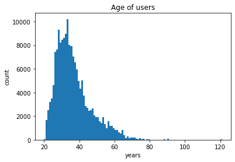

```python
bins = np.arange(20,121+1,1)
plt.hist(data = gobike, x = 'age',bins = bins);
plt.xlabel('years');
plt.title('Age of users');
plt.ylabel('count');
```

## The majority of the users seems to be between 20 and 45 years old.

# How man Males and Females are using the service ?

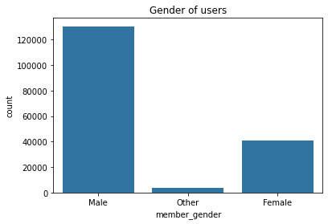

```python
sb.countplot( data = gobike, x = 'member_gender', color = base_color);
plt.title('Gender of users');
```

## The plot shows that users are mostly males.

# What is the number of Subscribers and customers in the data ?

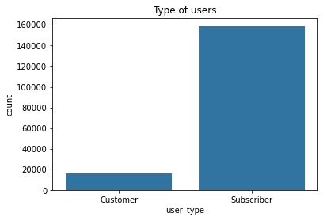

```python
sb.countplot( data = gobike, x = 'user_type', color = base_color);
plt.title('Type of users');
```

## The plot shows that the most of users are Subscribers.

# How's the trips distriputed over the Week?

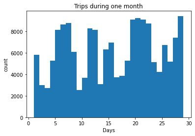

```python
bins = np.arange(1,29+1,1);
plt.hist( data = gobike, x = 'start_day', bins = bins);
plt.title('Trips during one month');
plt.xlabel('Days');
plt.ylabel('count');
```

## It appears that trips are more in the middle of the week than the weekend.

# What is the distribution of trips during the day?

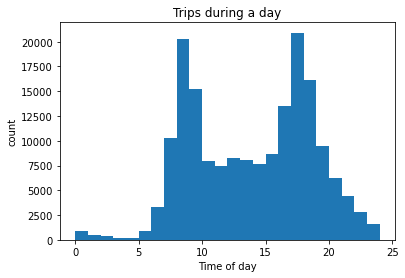

```python
bins = np.arange(0,24+1,1);
plt.hist( data = gobike, x = 'start_hour', bins = bins);
plt.title('Trips during a day');
plt.xlabel('Time of day');
plt.ylabel('count');
```

## It seems like people use the service at 8:00 and 18:00 which are the times people go to work and come back.

# What is the average trip duration ?

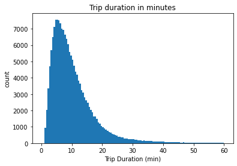

```python
bins = np.arange(0,60+0.5,0.5)
plt.hist( data = gobike, x = 'duration_min',bins = bins);
plt.xlabel('Trip Duration (min)');
plt.title('Trip duration in minutes');
plt.ylabel('count');
```

## The average trip duration is 11 minutes.

### Of the features you investigated, were there any unusual distributions? Did you perform any operations on the data to tidy, adjust, or change the form of the data? If so, why did you do this?

- I dropped the missing values and also I changed the start data into datetime format and also i extracted years,months and days into seperate columns to facilitate the analysis.
- I added a duration column in minutes to facilitate the analysis.

## Bivariate Exploration

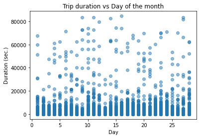

```python
sb.regplot( data = gobike, x = 'start_day',y = 'duration_sec',scatter_kws = {'alpha' : 1/2}, fit_reg = False );
plt.xlabel('Day');
plt.ylabel('Duration (sec.)');
plt.title('Trip duration vs Day of the month');
```

## The above graph shows that most of days are nearly equal in duration which is less than 200mins, and there are less trips with higher durations.

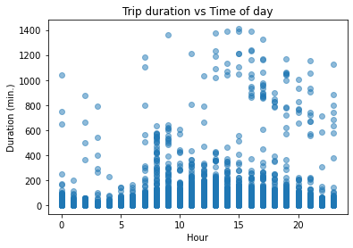

```python
sb.regplot( data = gobike, x = 'start_hour',y = 'duration_min',scatter_kws = {'alpha' : 0.5}, fit_reg = False );
plt.xlabel('Hour');
plt.ylabel('Duration (min.)');
plt.title('Trip duration vs Time of day');
```

## With further exploration it seems like the longer trips are usually after 12.

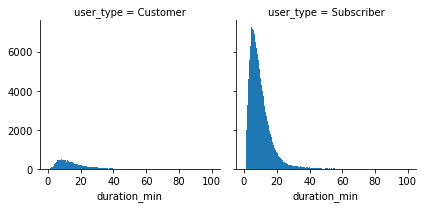

```python
bins = np.arange(0,100+0.5,0.5)
g = sb.FacetGrid( data = gobike , col = 'user_type');
g.map(plt.hist, 'duration_min',bins = bins);
```